# Portfoliomanagement and Financial Analysis - Assignment 4

Submit until Monday 2020-10-12, 13:00

Schwaiger, Dominik

```r
pacman::p_load(tidyverse,tidyquant,PortfolioAnalytics,nloptr)
```

**Please** remember to put your assignment solutions in `rmd` format using **many** chunks and putting readable text in between, similar to my examples given in Research Methods and Assignment 1! Also, each student has to select his own set of 10 stocks having data available as of `2000-01-01`. Select by Sharpe-ratio, dominance or any other method (e.g. matching your first name).

For all exercises: Please use the Assignment-Forum to post your questions, I will try my best to help you along!

## Exercise 1: Rebalancing

Have a look at `vignette("ROI_vignette")` and the `optimize.portfolio.rebalancing` command. Use your dataset to compute

```r
install.packages("tidyquant")
```

```
Error in install.packages : Updating loaded packages
```

```r
install.packages("quantmod")
```

```
Error in install.packages : Updating loaded packages
```

```r
require(quantmod)
require(tidyquant)
require(tidyverse)
library(quantmod)
require(ISR)
#vignette("ROI_vignette")
suppressMessages(library(PortfolioAnalytics))
suppressMessages(library(foreach))
suppressMessages(library(iterators))
suppressMessages(library(ROI))
suppressMessages(library(ROI.plugin.quadprog))
suppressMessages(library(ROI.plugin.glpk))
```

```r
stockselection <- c("AAPL", "MSFT", "AMZN", "JPM")

stock.prices <- stockselection %>%
  tq_get(get  = "stock.prices", from = "2000-01-01",to = "2019-08-31") %>%
  group_by(symbol)
```

```
Restarting R session...
```

1. Mean-Return (tangency portfolio)

First, we create the mean-return portfolio. We add the full investment constraint to it. Then, we add the objective to it.

```r
# Create portfolio object
portf_maxret <- portfolio.spec(assets=stockselection)
# Add constraints to the portfolio object
portf_maxret <- add.constraint(portfolio=portf_maxret, type="full_investment")
portf_maxret <- add.constraint(portfolio=portf_maxret, type="box", ## doesnt work!!
                               min=c(0.02, 0.05, 0.03, 0.02),
                               max=c(0.55, 0.6, 0.65, 0.5))
# Add objective to the portfolio object
portf_maxret <- add.objective(portfolio=portf_maxret, type="return", name="mean")
```

```r
summary(portf_maxret)
```

```
$assets
AAPL MSFT AMZN  JPM
0.25 0.25 0.25 0.25

$enabled_constraints
$enabled_constraints[[1]]
$type
[1] "full_investment"

$enabled
[1] TRUE

$message
[1] FALSE

$min_sum
[1] 1

$max_sum
[1] 1

$call
add.constraint(portfolio = portf_maxret, type = "full_investment")

attr(,"class")
[1] "weight_sum_constraint" "constraint"

$enabled_constraints[[2]]
$type
[1] "box"

$enabled
[1] TRUE

$min
AAPL MSFT AMZN  JPM
0.02 0.05 0.03 0.02

$max
AAPL MSFT AMZN  JPM
```

[output cut: 27 more lines]

```
$multiplier
[1] -1

$call
add.objective(portfolio = portf_maxret, type = "return", name = "mean")

attr(,"class")
[1] "return_objective" "objective"


$disabled_objectives
list()

attr(,"class")
[1] "summary.portfolio"
```

Now, we run the optimization of our portfolio.

```r
# Run the optimization
opt_maxret <- optimize.portfolio(R=stock.returns.monthly_xts, portfolio=portf_maxret,
                                 optimize_method="ROI", trace=TRUE)
print(opt_maxret)
```

```
PortfolioAnalytics Optimization

Call:
optimize.portfolio(R = stock.returns.monthly_xts, portfolio = portf_maxret,
    optimize_method = "ROI", trace = TRUE)

Optimal Weights:
AAPL MSFT AMZN  JPM
0.55 0.05 0.38 0.02

Objective Measure:
   mean
0.02268
```

```r
summary(opt_maxret)
```

```
PortfolioAnalytics Optimization Summary

Call:
optimize.portfolio(R = stock.returns.monthly_xts, portfolio = portf_maxret,
    optimize_method = "ROI", trace = TRUE)

Optimal Weights:
AAPL MSFT AMZN  JPM
0.55 0.05 0.38 0.02

Objective Measures:
   mean
0.02268


Portfolio Assets and Initial Weights:
AAPL MSFT AMZN  JPM
0.25 0.25 0.25 0.25

PortfolioAnalytics Portfolio Specification

Call:
portfolio.spec(assets = stockselection)

Number of assets: 4
Asset Names
[1] "AAPL" "MSFT" "AMZN" "JPM"

Constraints
Enabled constraint types
        - full_investment
        - box

Objectives:
Enabled objective names
        - mean

Constraints
Leverage Constraint:
min_sum = 1
```

[output cut: 52 more lines]

```
$enabled
[1] TRUE

$multiplier
[1] -1

$call
add.objective(portfolio = portf_maxret, type = "return", name = "mean")

attr(,"class")
[1] "return_objective" "objective"


Elapsed Time:
Time difference of 0.1884754 secs
```

```r
names(opt_maxret)
```

```
 [1] "weights"            "objective_measures"
 [3] "opt_values"         "out"
 [5] "call"               "portfolio"
 [7] "R"                  "data_summary"
 [9] "elapsed_time"       "end_t"
```

```r
extractStats(opt_maxret)
```

```
      mean        out     w.AAPL     w.MSFT     w.AMZN
 0.0226822 -0.0226822  0.5500000  0.0500000  0.3800000
     w.JPM
 0.0200000
```

```r
extractWeights(opt_maxret)
```

```
AAPL MSFT AMZN  JPM
0.55 0.05 0.38 0.02
```

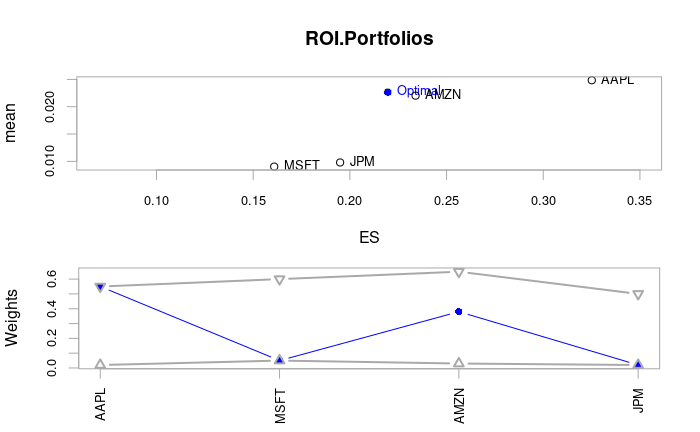

```r
plot(opt_maxret, chart.assets=TRUE, xlim=c(0.07, 0.35))
```

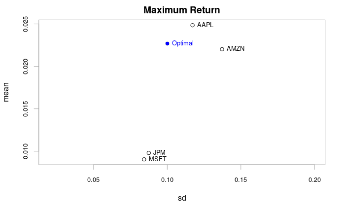

```r
chart.RiskReward(opt_maxret,return.col="mean", risk.col="sd",
                 chart.assets=TRUE, xlim=c(0.02, 0.2), main="Maximum Return")
```

Now, we run the optimization.

```r
# Run the optimization
opt_gmv <- optimize.portfolio(R=stock.returns.monthly_xts, portfolio=portf_maxret,
                              optimize_method="ROI", trace=TRUE)
print(opt_gmv)
```

```
PortfolioAnalytics Optimization

Call:
optimize.portfolio(R = stock.returns.monthly_xts, portfolio = portf_maxret,
    optimize_method = "ROI", trace = TRUE)

Optimal Weights:
AAPL MSFT AMZN  JPM
0.55 0.05 0.38 0.02

Objective Measure:
   mean
0.02268
```

[figure not shown]

```r
bt_gmv <- optimize.portfolio.rebalancing(R=stock.returns.monthly_xts,portfolio=portf_minvar,
                                         optimize_method="ROI",
                                         rebalance_on="quarters",
                                         training_period=36)

chart.Weights(bt_gmv)
```

```r
returns_gmv <- Return.portfolio(R = stock.returns.daily_xts, weights = extractWeights(bt_gmv))
```

2. Minimum-Variance

*Minimizing Portfolio Variance*

Now, we want to minimize the variance of our portfolo. Therefore, we create a portfolio object, add the full investment constraint to it and set the objective to risk mimimizing.

```r
# Create portfolio object
portf_minvar <- portfolio.spec(assets=stockselection)
# Add full investment constraint to the portfolio object
portf_minvar <- add.constraint(portfolio=portf_minvar, type="full_investment")
# Add objective to minimize variance
portf_minvar <- add.objective(portfolio=portf_minvar, type="risk", name="var")
```

*Constrained Minimum Variance Portfolio*

Next, we add the long only constraints and group constraints.

```r
# Add long only constraints
portf_minvar <- add.constraint(portfolio=portf_minvar, type="box",
                               min=0, max=1)
# Add group constraints
portf_minvar <- add.constraint(portfolio=portf_minvar,
                               type="group",
                               groups=list(groupA=1,
                                           groupB=c(2, 3),
                                           groupC=4),
                               group_min=c(0, 0.25, 0.10),
                               group_max=c(0.45, 0.6, 0.5))
```

*Optimization*

Next, we run the optimization.

```r
# Run the optimization
opt_minvar <- optimize.portfolio(R=stock.returns.monthly_xts, portfolio=portf_minvar,
                                 optimize_method="ROI", trace=TRUE)
print(opt_minvar)
```

```
PortfolioAnalytics Optimization

Call:
optimize.portfolio(R = stock.returns.monthly_xts, portfolio = portf_minvar,
    optimize_method = "ROI", trace = TRUE)

Optimal Weights:
  AAPL   MSFT   AMZN    JPM
0.1131 0.4122 0.0515 0.4231

Objective Measure:
 StdDev
0.07051
```

```r
bt_minvar <- optimize.portfolio.rebalancing(R=stock.returns.monthly_xts, portfolio=portf_minvar,
                                            optimize_method="ROI",
                                            rebalance_on="quarters",
                                            training_period=36)

bt_minvar
```

```
PortfolioAnalytics Optimization with Rebalancing

Call:
optimize.portfolio.rebalancing(R = stock.returns.monthly_xts,
    portfolio = portf_minvar, optimize_method = "ROI", rebalance_on = "quarters",
    training_period = 36)

Number of rebalancing dates:  68
First rebalance date:
[1] "2002-12-31"
Last rebalance date:
[1] "2019-08-30"

Annualized Portfolio Rebalancing Return:
[1] 0.1685158

Annualized Portfolio Standard Deviation:
[1] 0.1996948
```

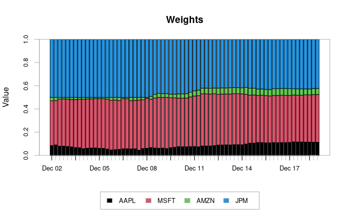

```r
chart.Weights(bt_minvar)
```

```r
returns_minvar <- Return.portfolio(R = stock.returns.daily_xts, weights = extractWeights(bt_minvar))
```

3. Maximum Quadratic Utility Portfolios

*Maximizing Quadratic Utility*

Now, we want to maximize quadratic utility. For this, we create an initial portfolio object, set the constraint to full_investment and long only. We combine the constraints into a list. Afterwards, we create the return objective and combine all with the risk aversion parameter. The risk aversion parameter specifys how variance is ok. We combine the objects into a list

```r
# Create initial portfolio object
init_portf <- portfolio.spec(assets=stockselection)
# Create full investment constraint
fi_constr <- weight_sum_constraint(type="full_investment")
# Create long only constraint
lo_constr <- box_constraint(type="long_only", assets=init_portf$assets)
# Combine the constraints in a list
qu_constr <- list(fi_constr, lo_constr)
# Create return objective
ret_obj <- return_objective(name="mean")
# Create variance objective specifying a risk_aversion parameter which controls
# how much the variance is penalized
var_obj <- portfolio_risk_objective(name="var", risk_aversion=0.25)
# Combine the objectives into a list
qu_obj <- list(ret_obj, var_obj)
```

Now, we run the optimization.

```r
# Run the optimization
opt_qu <- optimize.portfolio(R=stock.returns.monthly_xts, portfolio=init_portf,
                             constraints=qu_constr,
                             objectives=qu_obj,
                             optimize_method="ROI",
                             trace=TRUE)
opt_qu
```

```
PortfolioAnalytics Optimization

Call:
optimize.portfolio(R = stock.returns.monthly_xts, portfolio = init_portf,
    constraints = qu_constr, objectives = qu_obj, optimize_method = "ROI",
    trace = TRUE)

Optimal Weights:
  AAPL   MSFT   AMZN    JPM
0.9046 0.0000 0.0954 0.0000

Objective Measure:
   mean
0.02458


StdDev
0.1117
```

```r
bt_qu <- optimize.portfolio.rebalancing(R=stock.returns.monthly_xts, portfolio=init_portf,
                                        constraints=qu_constr,
                                        objectives=qu_obj,
                                        optimize_method="ROI",
                                        rebalance_on="quarters",
                                        training_period=36)
print(bt_qu)
```

```
PortfolioAnalytics Optimization with Rebalancing

Call:
optimize.portfolio.rebalancing(R = stock.returns.monthly_xts,
    portfolio = init_portf, constraints = qu_constr, objectives = qu_obj,
    optimize_method = "ROI", rebalance_on = "quarters", training_period = 36)

Number of rebalancing dates:  68
First rebalance date:
[1] "2002-12-31"
Last rebalance date:
[1] "2019-08-30"

Annualized Portfolio Rebalancing Return:
[1] 0.3162216

Annualized Portfolio Standard Deviation:
[1] 0.3132041
```

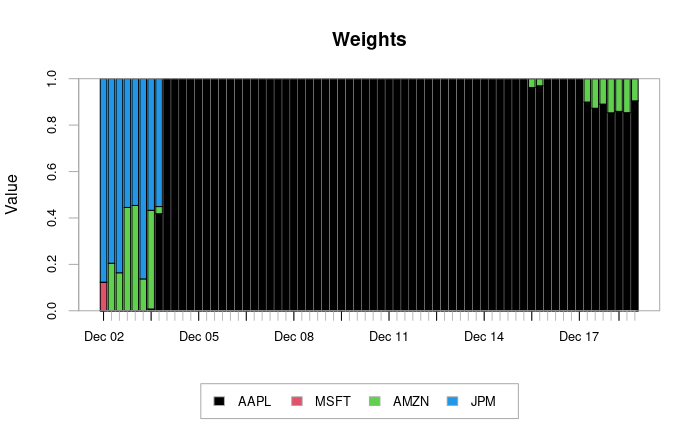

```r
chart.Weights(bt_qu)
```

```r
returns_qu <- Return.portfolio(R = stock.returns.daily_xts, weights = extractWeights(bt_qu))
```

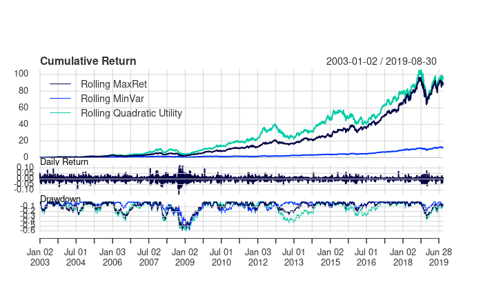

```r
library(PerformanceAnalytics)
p.returns<-merge(returns_maxret, returns_minvar, returns_qu)
names(p.returns)<-c("Rolling MaxRet", "Rolling MinVar", "Rolling Quadratic Utility")

PerformanceAnalytics::charts.PerformanceSummary(p.returns, colorset=rich6equal,
                          lwd=1, cex.legend = 1.0, event.labels = TRUE, main = "")
```

## Exercise 2: Custom moments function

Check `vignette("custom_moments_objectives")` to implement a variety of robust covariance matrix estimates (see `?MASS::cov.rob`, `?PerformanceAnalytics::ShrinkageMoments` and maybe `?PerformanceAnalytics::EWMAMoments` - the latter one only for backtesting) for the minimum variance and quadratic utility portfolios. Plot the different Efficient frontiers, optimal portfolios and weights and visualize the different covariances. Also make yourselves comfortable with cleaning outliers from your timeseries via `return.Clean()`.

**Get Data of 10 Stocks** First, we get Data of our 10 Stocks. We use the same as in the previous assignment - all stocks are below are listed in the S&P500. We create a vector which contains all stocks we want to observe. Then, we get the stock prices from 2000-01-01 to 2020-09-30 and create monthly returns.

```r
require(timetk)

stockselection <- c("AMZN","ADBE","MSFT","JNJ","PG","AXP","BAC","AAPL","T","CAT")

stock.prices <- stockselection %>%
  tq_get(get  = "stock.prices", from = "2000-01-01",to = "2020-09-30") %>%
  group_by(symbol)

stock.returns.monthly <- stock.prices %>%
  tq_transmute(select = adjusted,
               mutate_fun = periodReturn,
               period="monthly",
               type="arithmetic",
               col_rename = "Stock.returns"
               )
options(max.print=60)
stock.returns.monthly
```

| symbol | date | Stock.returns |
| --- | --- | --- |
| AMZN | 2000-01-31 | -0.277622378 |
| AMZN | 2000-02-29 | 0.066795741 |
| AMZN | 2000-03-31 | -0.027223230 |
| AMZN | 2000-04-28 | -0.176305970 |
| AMZN | 2000-05-31 | -0.124575311 |
| AMZN | 2000-06-30 | -0.248382924 |
| AMZN | 2000-07-31 | -0.170395869 |
| AMZN | 2000-08-31 | 0.377593361 |
| AMZN | 2000-09-29 | -0.073795181 |
| AMZN | 2000-10-31 | -0.047154472 |

[output cut: 50 more lines]

Now, we make 10 columns (each for every stock) with the simple returns from adjusted prices and convert to xts.

With the command “return.clean”, we clean the returns the outliners. We use the methods “boudt”.

```r
stock.returns.monthly_xts_with_outliers <- pivot_wider(stock.returns.monthly,
                                                names_from = symbol,
                                                values_from = c(Stock.returns))%>%
  tk_xts(date_var = date, silent = TRUE)

stock.returns.monthly_xts <- Return.clean(stock.returns.monthly_xts_with_outliers, method = "boudt", alpha = 0.01)
options(max.print=60)
stock.returns.monthly_xts
```

[output not shown]

**Now, we create the initial minimum variance portfolio**

In a first step, we require the necessary packages. Then, we construct the initial portfolio with basic constraints. We construct the portfolio in a way that R minimizes the standard deviation.

```r
require(PortfolioAnalytics)
require(DEoptim)
require(ROI)
require(ROI.plugin.glpk)
require(ROI.plugin.quadprog)
```

Now, we construct the initial portfolio with basic constraints.

```r
init.port.minv <- portfolio.spec(assets=colnames(stock.returns.monthly_xts),category_labels = stockselection)
init.port.minv <- add.constraint(portfolio=init.port.minv, type="full_investment")
init.port.minv <- add.constraint(portfolio=init.port.minv, type="long_only")

init.port.minv
```

[output not shown]

Next, we construct the portfolio with standard deviation as an objective.

```r
SD.port.minv <- add.objective(portfolio=init.port.minv, type="risk", name="StdDev")
SD.port.minv
```

```
PortfolioAnalytics Portfolio Specification

Call:
portfolio.spec(assets = colnames(stock.returns.monthly_xts),
    category_labels = stockselection)

Number of assets: 10
Asset Names
 [1] "AMZN" "ADBE" "MSFT" "JNJ"  "PG"   "AXP"  "BAC"  "AAPL" "T"    "CAT"

Category Labels
AMZN : AMZN
ADBE : ADBE
MSFT : MSFT
JNJ : JNJ
PG : PG
AXP : AXP
BAC : BAC
AAPL : AAPL
T : T
CAT : CAT


Constraints
Enabled constraint types
        - full_investment
        - long_only

Objectives:
Enabled objective names
        - StdDev
```

**Next, we create initial maximum quadratic utility portfolio.**

We construct the initial quadratic utility portfolio with the basic constraints ( fullinvestment, long_only).

```r
# Construct initial portfolio with basic constraints.
init.port.maxq <- portfolio.spec(assets=colnames(stock.returns.monthly_xts),category_labels = stockselection)

#init.port.maxq <- add.constraint(init.port.maxq, type = "box", min = 0, max = 1)
init.port.maxq <- add.constraint(portfolio=init.port.maxq, type="full_investment")
init.port.maxq <- add.constraint(portfolio=init.port.maxq, type="long_only")

#Portfolio with standard deviation as an objective
SD.port.maxq <- add.objective(portfolio=init.port.maxq, type="return", name="mean")
SD.port.maxq <- add.objective(portfolio=SD.port.maxq, type="risk", name="var", risk_aversion=0.25)
```

**function to estimate covariance matrix with cov.rob for minimum variance**

```r
sigma.robust <- function(R){
    require(MASS)
    out <- list()
    out$sigmarob <- cov.rob(R, method="mcd")$cov
    return(out)
}

sigmarob <- sigma.robust(stock.returns.monthly_xts)$sigmarob
sigmarob
```

[output not shown]

**function to estimate covariance matrix with ShrinkageMoments for minimum variance**

```r
sigma.robust.shrink <- function(R){
    targets <- c(1,3,4)
    f <- rowSums(stock.returns.monthly_xts)
    out <- list()
    out$sigmashrink <- M2.shrink(stock.returns.monthly_xts, targets, f)$M2sh
    return(out)
}
sigma.shrink <- sigma.robust.shrink(stock.returns.monthly_xts)$sigmashrink
```

[output not shown]

**Optimize portfolios**

```r
opt.sd.minv <- optimize.portfolio(stock.returns.monthly_xts, SD.port.minv, optimize_method="ROI", momentFUN="sigma.robust", trace = TRUE)
```

[output not shown]

**Plot the covariance matrix from cov.rob**

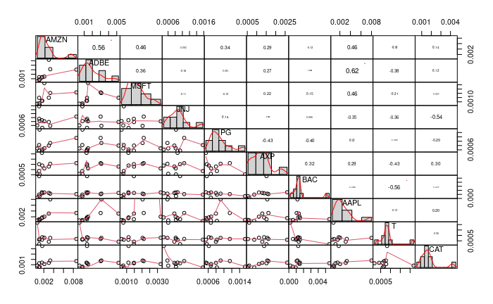

**Plot the covariance matrix from shrink**

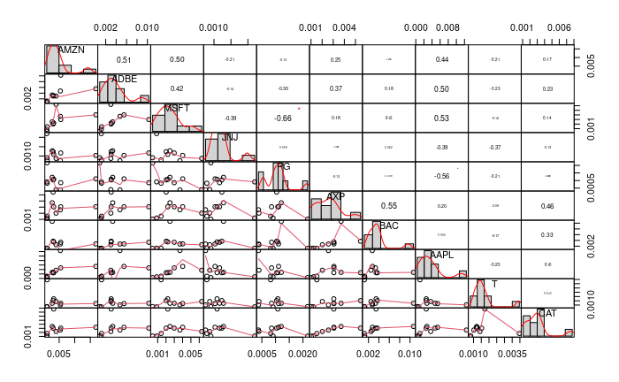

**Plot the Portfolios**

[figure not shown]

```r
plot(opt.sd.minv, risk.col="StdDev", return.col="mean", main="Minimum Variance Optimization", chart.assets=TRUE, xlim=c(0, 0.2), ylim=c(0,0.02))
```

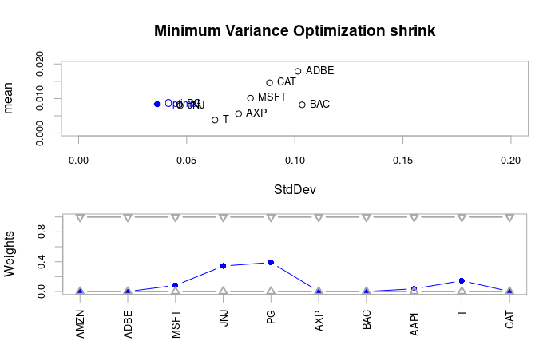

```r
plot(opt.sd.minv.shrink, risk.col="StdDev", return.col="mean", main="Minimum Variance Optimization shrink", chart.assets=TRUE, xlim=c(0, 0.2), ylim=c(0,0.02))
```

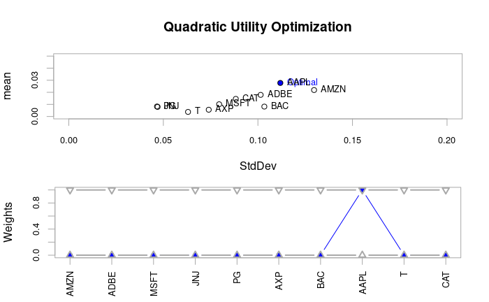

```r
plot(opt.sd.maxq, risk.col="StdDev", return.col="mean", main="Quadratic Utility Optimization", chart.assets=TRUE, xlim=c(0, 0.2), ylim=c(0,0.05))
```

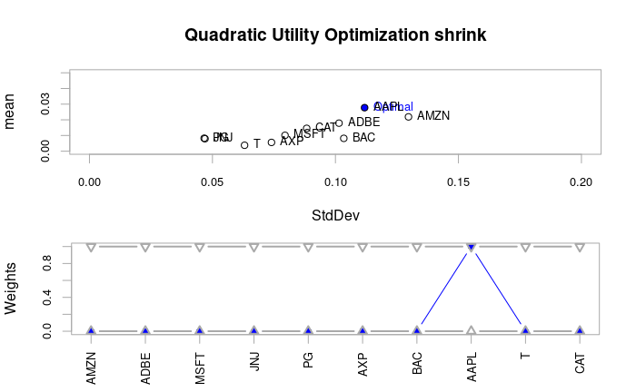

```r
plot(opt.sd.maxq.shrink, risk.col="StdDev", return.col="mean", main="Quadratic Utility Optimization shrink", chart.assets=TRUE, xlim=c(0, 0.2), ylim=c(0,0.05))
```

**Chart Efficient Frontiert for the minimum variance Portfolio**

```
executing %dopar% sequentially: no parallel backend registered
```

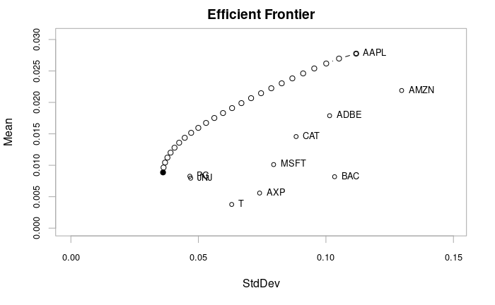

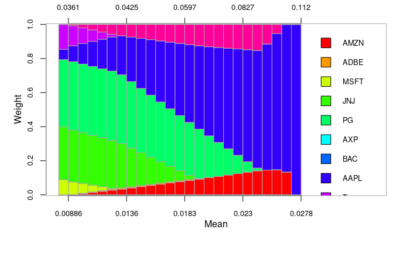

**Chart Efficient Frontiert for the quadratic utility Portfolio**

[figure not shown]

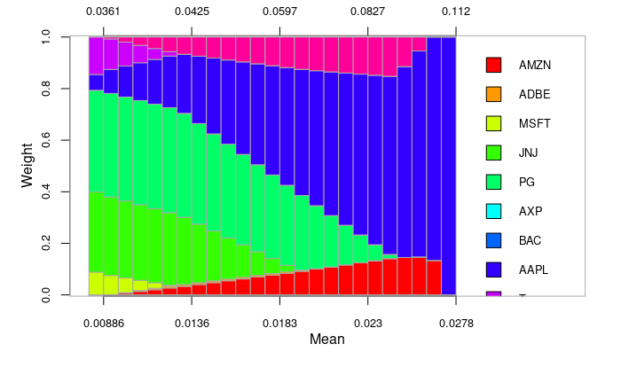

## Exercise 3: Regime Switching

Have a look at `demo(regime_switching)` and estimate and rebalance portfolios based on 2/3 regimes. Can you plot the regimes over time?

First, we load the package.

```r
#' Load package and data.
library(PortfolioAnalytics)
```

First, we get the monthly stock returns for the S&P500 from 2000-01-01 to 2020-09-30.

```r
# get monthly stock returns from the S&P500
monthly_returnsSP500 <- "^GSPC" %>%
  tq_get(get = "stock.prices", from = "2000-01-01", to = "2020-09-30") %>%
  tq_transmute(adjusted, periodReturn, period = "monthly", col_rename = "returns SP500")
monthly_returnsSP500
```

| date | returns SP500 |
| --- | --- |
| 2000-01-31 | -0.041753145 |
| 2000-02-29 | -0.020108083 |
| 2000-03-31 | 0.096719828 |
| 2000-04-28 | -0.030795756 |
| 2000-05-31 | -0.021915051 |
| 2000-06-30 | 0.023933550 |
| 2000-07-31 | -0.016341276 |
| 2000-08-31 | 0.060699105 |
| 2000-09-29 | -0.053482975 |
| 2000-10-31 | -0.004949486 |

[output cut: 50 more lines]

Now, we calculate the rolling monthly mean.

```r
#calculate the rolling mean monthly

rollmeanSP500 <- rollmean(monthly_returnsSP500[, "returns SP500"], 2)
rollmeanSP500
```

```
       returns SP500
  [1,] -0.0309306140
  [2,]  0.0383058725
  [3,]  0.0329620364
  [4,] -0.0263554030
  [5,]  0.0010092495
  [6,]  0.0037961367
  [7,]  0.0221789145
  [8,]  0.0036080652
  [9,] -0.0292162303
 [10,] -0.0425090479
 [11,] -0.0380075822
 [12,]  0.0193450113
 [13,] -0.0288270794
 [14,] -0.0782477232
```

[output cut: 221 more lines]

Now, we create the vecotr with the rollinng monthly mean of the S&P500. 2 - good economy 1 - bad economy

```r
vector <- c(rollmeanSP500)

#2=good economy, 1=bad economy
regime1or2 <-as.numeric(vector>0)+1
regime1or2
```

```
  [1] 1 2 2 1 2 2 2 2 1 1 1 2 1 1 2 2 1 1 1 1 1 2 2 1
 [25] 1 2 1 1 1 1 1 1 1 2 1 1 1 1 2 2 2 2 2 2 2 2 2 2
 [49] 2 1 1 1 2 1 1 2 2 2 2 2 1 1 1 2 2 2 2 1 1 2 2 2
 [73] 2 2 2 1 1 2 2 2 2 2 2 2 1 1 2 2 2 1 1 2 2 1 1 1
 [97] 1 1 2 2 1 1 2 1 1 1 1 1 1 1 2 2 2 2 2 2 2 2 2 1
[121] 1 2 2 1 1 2 2 2 2 2 2 2 2 2 2 2 1 1 1 1 2 2 2 2
[145] 2 2 2 1 1 2 2 2 2 1 2 2 2 2 2 2 2 2 2 1 2 2 2 1
[169] 2 2 2 2 2 2 2 2 2 2 2 1 2 2 1 2 1 1 1 1 2 2 1 1
[193] 1 2 2 2 2 2 2 1 1 2 2 2 2 2 2 2 2 2 2 2 2 2 2 2
[217] 2 1 1 2 2 2 2 2 1 1 1 1 2 2 2 1 2 2 1
```

The regime 1 is a scenario with a bad market, and regirme 2 is a scenario with a good market. We convert it into xts.

```r
SP500dates <- select(monthly_returnsSP500,date)


#regime 1 is bad market phase (1) and regime 2 is good market phase (2)
data_frame <- data.frame(SP500dates[2:236,], regime1or2)
data_frame
```

| date | regime1or2 |
| --- | --- |
| 2000-02-29 | 1 |
| 2000-03-31 | 2 |
| 2000-04-28 | 2 |
| 2000-05-31 | 1 |
| 2000-06-30 | 2 |
| 2000-07-31 | 2 |
| 2000-08-31 | 2 |
| 2000-09-29 | 2 |
| 2000-10-31 | 1 |
| 2000-11-30 | 1 |

[output cut: 50 more lines]

```r
#convert it in xts format
regime_xts <- data_frame %>%
  select(date,regime1or2) %>%
  tk_xts(silent = TRUE)
regime_xts
```

```
           regime1or2
2000-02-29          1
2000-03-31          2
2000-04-28          2
2000-05-31          1
2000-06-30          2
2000-07-31          2
2000-08-31          2
2000-09-29          2
2000-10-31          1
2000-11-30          1
2000-12-29          1
2001-01-31          2
2001-02-28          1
2001-03-30          1
2001-04-30          2
2001-05-31          2
2001-06-29          1
2001-07-31          1
2001-08-31          1
2001-09-28          1
2001-10-31          1
2001-11-30          2
2001-12-31          2
2002-01-31          1
2002-02-28          1
2002-03-28          2
2002-04-30          1
2002-05-31          1
2002-06-28          1
2002-07-31          1
2002-08-30          1
2002-09-30          1
2002-10-31          1
2002-11-29          2
2002-12-31          1
2003-01-31          1
2003-02-28          1
2003-03-31          1
2003-04-30          2
```

[output cut: 181 more lines]

```
2018-06-29          2
2018-07-31          2
2018-08-31          2
2018-09-28          2
2018-10-31          1
2018-11-30          1
2018-12-31          1
2019-01-31          1
2019-02-28          2
2019-03-29          2
2019-04-30          2
2019-05-31          1
2019-06-28          2
2019-07-31          2
2019-08-30          1
```

Now, we get our stock selection and transmute them to returns. We create monthly returns.

We make a tiblle with dates and returns for all stocks. We make 10 colums (each for every stock) with the simple returns from adjusted prices and convert to xts. This is necessary Portfolioanalytics.

```r
R <- pivot_wider(stock.returns.monthly,names_from = symbol,values_from = c(Stock.returns))%>%
  tk_xts(date_var = date, silent = TRUE)


colnames(R) <- c("AMZN","ADBE","MSFT","JNJ","PG","AXP","BAC","AAPL","T","CAT")
funds <- colnames(R)

R %>% head()
```

```
                  AMZN        ADBE        MSFT         JNJ          PG          AXP         BAC        AAPL            T
2000-01-31 -0.27762238 -0.16015265 -0.16032215 -0.06644040 -0.05455526  0.049254574  0.00000000 -0.07314362 -0.082789815
2000-02-29  0.06679574  0.85244078 -0.08684527 -0.16038460 -0.13048913 -0.185508197 -0.05032219  0.10481882 -0.119533166
2000-03-31 -0.02722323  0.09156627  0.18881176 -0.02430583 -0.35419597  0.109920767  0.15247242  0.18484224  0.115894063
2000-04-28 -0.17630597  0.08646839 -0.34352958  0.17437759  0.05776896  0.005506193 -0.06555429 -0.08651687  0.045790437
2000-05-31 -0.12457531 -0.06925072 -0.10304665  0.08878530  0.11297065  0.083612071  0.14176937 -0.32292179 -0.002853657
2000-06-30 -0.24838292  0.15514615  0.27872078  0.13826804 -0.14661666 -0.034721798 -0.22435225  0.24702517  0.007153251
                   CAT
2000-01-31 -0.11618770
2000-02-29 -0.17378527
2000-03-31  0.12477698
2000-04-28  0.01641412
2000-05-31 -0.03011098
2000-06-30 -0.11437894
```

```r
port1 <- portfolio.spec(funds)
port1 <- add.constraint(port1, "weight_sum", min_sum=0.99, max_sum=1.01)
port1 <- add.constraint(port1, "box", min=0.05, max=0.5)
port1 <- add.objective(port1, type="risk", name="ES", arguments=list(p=0.9))
port1 <- add.objective(port1, type="risk_budget", name="ES",
                       arguments=list(p=0.9), max_prisk=0.5)
```

Now, we can extract which regime portfolio we optimized with each rebalance date. In case something structurally changes in our data, maybe a date fits better in the other regime.

```r
#' We can extract which regime portfolio we optimized with at each rebalance date.

#if there are structural changes in the data series, maybe a date fits better in the other regime now
lapply(opt.rebal$opt_rebalancing, function(x) x$regime)
```

```
$`2010-12-31`
[1] 2

$`2011-03-31`
[1] 2

$`2011-06-30`
[1] 1

$`2011-09-30`
[1] 1

$`2011-12-30`
[1] 2

$`2012-03-30`
[1] 2

$`2012-06-29`
[1] 1

$`2012-09-28`
[1] 2

$`2012-12-31`
[1] 2

$`2013-03-28`
[1] 2

$`2013-06-28`
[1] 2

$`2013-09-30`
[1] 1

$`2013-12-31`
[1] 2

$`2014-03-31`
```

[output cut: 40 more lines]

```

$`2017-09-29`
[1] 2

$`2017-12-29`
[1] 2

$`2018-03-29`
[1] 1

$`2018-06-29`
[1] 2

$`2018-08-30`
[1] 1
```

Now, we extract the optimal weights at each rebalance date.

```r
#' Extract the optimal weights at each rebalance date.
wt <- extractWeights(opt.rebal)
wt
```

[output not shown]

[output cut: 11 more lines]

[output not shown]

Next, we extract the objective measures.

```r
#' Extract the objective measures*.
obj <- extractObjectiveMeasures(opt.rebal)
str(obj)
```

[output not shown]

```r
obj
```

[output not shown]

[output cut: 584 more lines]

```
2013-06-28                     0.4248516
2013-12-31                     0.4267297
2014-03-31                     0.4275065
2014-06-30                     0.4282676
2014-09-30                     0.4262417
2014-12-31                     0.4310402
2015-03-31                     0.4299292
2016-03-31                     0.4253854
2016-06-30                     0.4262433
2016-12-30                     0.4232628
2017-03-31                     0.4232725
2017-06-30                     0.4237087
2017-09-29                     0.4241911
2017-12-29                     0.4319386
2018-06-29                     0.4411036
```

In this step, we extract the stats.

```r
# Extract the stats*.
xt <- extractStats(opt.rebal)
str(xt)
```

[output not shown]

[output cut: 76 more lines]

```
  .. ..- attr(*, "dimnames")=List of 2
  .. .. ..$ : chr [1:3997] ".rnd.portf.1" ".rnd.portf.2" ".rnd.portf.3" ".rnd.portf.4" ...
  .. .. ..$ : chr [1:32] "ES" "ES.contribution.AAPL" "ES.contribution.MSFT" "ES.contribution.AMZN" ...
  ..$ : num [1:3997, 1:32] 0.0902 0.1149 0.0869 0.1027 0.0851 ...
  .. ..- attr(*, "dimnames")=List of 2
  .. .. ..$ : chr [1:3997] ".rnd.portf.1" ".rnd.portf.2" ".rnd.portf.3" ".rnd.portf.4" ...
  .. .. ..$ : chr [1:32] "ES" "ES.contribution.AAPL" "ES.contribution.MSFT" "ES.contribution.AMZN" ...
  ..$ : num [1:3997, 1:32] 0.0873 0.111 0.0844 0.0991 0.0826 ...
  .. ..- attr(*, "dimnames")=List of 2
  .. .. ..$ : chr [1:3997] ".rnd.portf.1" ".rnd.portf.2" ".rnd.portf.3" ".rnd.portf.4" ...
  .. .. ..$ : chr [1:32] "ES" "ES.contribution.AAPL" "ES.contribution.MSFT" "ES.contribution.AMZN" ...
  ..$ : num [1:3997, 1:32] 0.0865 0.1099 0.0837 0.0982 0.0819 ...
  .. ..- attr(*, "dimnames")=List of 2
  .. .. ..$ : chr [1:3997] ".rnd.portf.1" ".rnd.portf.2" ".rnd.portf.3" ".rnd.portf.4" ...
  .. .. ..$ : chr [1:32] "ES" "ES.contribution.AAPL" "ES.contribution.MSFT" "ES.contribution.AMZN" ...
```

This returns a list of n elements for n regimes. In this case, there may be different objectives/different numbers of objectives. This makes it difficult to return to a single xts object. Next, we extract the optimal weights at each rebalance date.

[figure not shown]

```r
#' *
#' Note that this returns a list of N elements for N regimes. We may have
#' different objectives and/or a different number of objectives which makes
#' returning a single xts object difficult/

#' Extract the optimal weights at each rebalance date.
chart.Weights(opt.rebal, colorset=rainbow10equal)
```

```r
wt
```

[output not shown]

[output cut: 11 more lines]

[output not shown]

Now, we chart the risk contribution for regime 1.

[figure not shown]

```r
#' Chart the risk contribution for regime 1
#
chart.RiskBudget(opt.rebal, match.col="ES", risk.type="percentage",
                 regime=1, colorset=rainbow10equal)
```

```r
opt2
```

[output not shown]

Now, we chart the risk contribution for regime 2.

[figure not shown]

```r
#' Chart the risk contribution for regime 2
chart.RiskBudget(opt.rebal, match.col="StdDev", risk.type="percentage",
                 regime=2, colorset=rainbow10equal)
```

```r
opt1
```

[output not shown]

## Exercise 4: Single Index-Model*

*Now we are going to estimate the Portfolio Input Parameters with the Single-Index Model. Use your ten assets and additionally choose the S&P500 as index (same returns etc).*

*a) Regress all stocks on the index. Show alpha, beta and residual variance. Calculate systematic and firm-specific risk. Are there any significant alphas? (You should double check with the appropriate `PerformanceAnalytics` Functions)*

*b) Extract the betas and calculate systematic and unsystematic risk, derive the whole covariance matrix. To do this you can use *CH15_Factor_Modfels_for_Asset_Returns.pdf (15.3.1)* and the code implemented in the function sharpeFactorEstimator that you find [here](http://financewithr.blogspot.com/2013/06/portfolio-optimization-using-single.html) (please do not just copy everything, but try to understand what you are doing, e.g. check why and if G.hat has the same values as found by the multivariate regression).*

*c) Now use the *custom-moments* functions from Exercise 2 to implement the single-factor model into the portfolio optimization framework and plot the efficient frontier using the parameters estimated by the single factor model next to the EF of the full-covariance model. Calculate MVP, TP etc. and work out the differences in weights, portfolio return and portfolio risk.*

### Get the packages

Now we are going to estimate the Portfolio Input Parameters with the Single-Index Model. Use your ten assets and additionally choose the S&P500 as index (same returns etc).

```r
stockselection_4 <- c("MO", "MDLZ", "PEP", "PM", "KHC", "T","WMT", "MSFT","BAC","PG", "^GSPC")
stockselection_4
```

```
 [1] "MO"    "MDLZ"  "PEP"   "PM"    "KHC"   "T"     "WMT"   "MSFT"  "BAC"   "PG"    "^GSPC"
```

```r
# Presettings
n <- length(stockselection_4)
#Get the prices of the stocks
stock.prices_4 <- stockselection_4 %>%
  tq_get(get  = "stock.prices", from = "2015-07-06",to = Sys.Date( )) %>% #First trade day of KHC
  group_by(symbol)
# Output the first two entries of each stock!
stock.prices_4 %>% slice(1:2)
```

| symbol | date | open | high | low | close | volume | adjusted |
| --- | --- | --- | --- | --- | --- | --- | --- |
| ^GSPC | 2015-07-06 | 2073.95 | 2078.61 | 2058.40 | 2068.76 | 3486360000 | 2068.76001 |
| ^GSPC | 2015-07-07 | 2069.52 | 2083.74 | 2044.02 | 2081.34 | 4458660000 | 2081.34009 |
| BAC | 2015-07-06 | 16.78 | 17.01 | 16.71 | 16.94 | 58726900 | 15.35557 |
| BAC | 2015-07-07 | 16.90 | 16.93 | 16.34 | 16.69 | 115450500 | 15.12896 |
| KHC | 2015-07-06 | 71.00 | 74.29 | 71.00 | 72.96 | 3809700 | 58.67768 |
| KHC | 2015-07-07 | 73.73 | 74.71 | 72.96 | 74.63 | 5794300 | 60.02078 |
| MDLZ | 2015-07-06 | 41.20 | 41.48 | 40.98 | 41.26 | 9044900 | 37.15101 |
| MDLZ | 2015-07-07 | 41.48 | 41.89 | 40.99 | 41.78 | 6288600 | 37.61922 |
| MO | 2015-07-06 | 48.88 | 49.89 | 48.76 | 49.87 | 7862700 | 37.75277 |
| MO | 2015-07-07 | 49.97 | 51.82 | 49.94 | 51.68 | 13341000 | 39.12297 |

[output cut: 12 more lines]

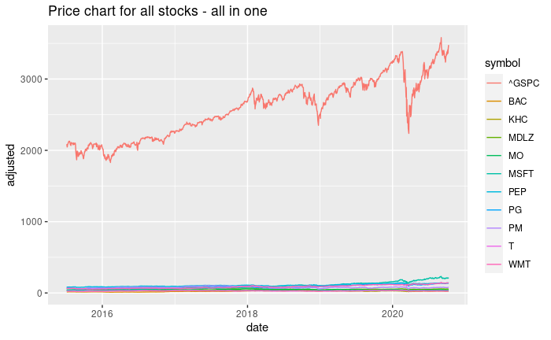

```r
stock.prices_4 %>%
  ggplot(aes(x = date, y = adjusted, color = symbol)) +
  geom_line() +
  ggtitle("Price chart for all stocks - all in one")
```

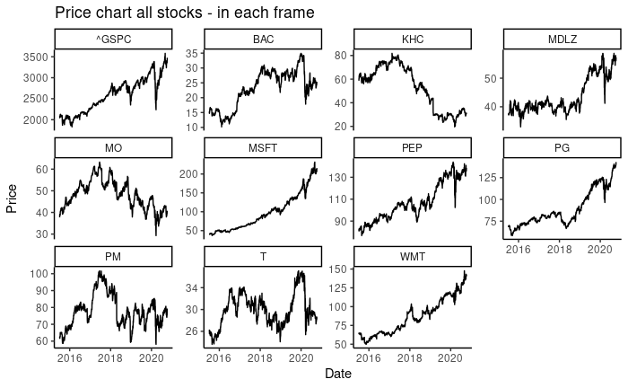

```r
# Plotting the stock prices in each frame
stock.prices_4 %>%
  ggplot(aes(x = date, y = adjusted)) +
  geom_line() +
  facet_wrap(~symbol, scales = "free_y") +
  theme_classic() +
  labs(x = "Date", y = "Price") +
  ggtitle("Price chart all stocks - in each frame")
```

```r
# Create monthly returns by the tq_transmute() = adds new variables to an existing tibble;
stock.returns.monthly_4 <- stock.prices_4 %>%
  tq_transmute(select = adjusted,
               mutate_fun = periodReturn,
               period="monthly",
               type="arithmetic",
               col_rename = "Stock.returns")
# Output the first two entries of each stock!
stock.returns.monthly_4 %>% slice(1:2)
```

| symbol | date | Stock.returns |
| --- | --- | --- |
| ^GSPC | 2015-07-31 | 0.01695706 |
| ^GSPC | 2015-08-31 | -0.06258082 |
| BAC | 2015-07-31 | 0.05549001 |
| BAC | 2015-08-31 | -0.08612998 |
| KHC | 2015-07-31 | 0.09689831 |
| KHC | 2015-08-31 | -0.08569256 |
| MDLZ | 2015-07-31 | 0.09379497 |
| MDLZ | 2015-08-31 | -0.06137804 |
| MO | 2015-07-31 | 0.09043506 |
| MO | 2015-08-31 | -0.01471137 |

[output cut: 12 more lines]

```r
# Make 10 columns (each for every stock) with the simple returns from adjusted prices and convert to xts
stock.returns.monthly_xts_4 <- pivot_wider(stock.returns.monthly_4,
                                                names_from = symbol,
                                                values_from = c(Stock.returns))%>%
   tk_xts(date_var = date, silent = TRUE)
# Output the first entries (simple returns from adjusted prices) of each stock!
stock.returns.monthly_xts_4[1]
```

```
                   MO       MDLZ        PEP         PM        KHC           T         WMT       MSFT        BAC
2015-07-31 0.09043506 0.09379497 0.02065667 0.05332519 0.09689831 -0.01144204 -0.00758285 0.05203882 0.05549001
                    PG      ^GSPC
2015-07-31 -0.03400332 0.01695706
```

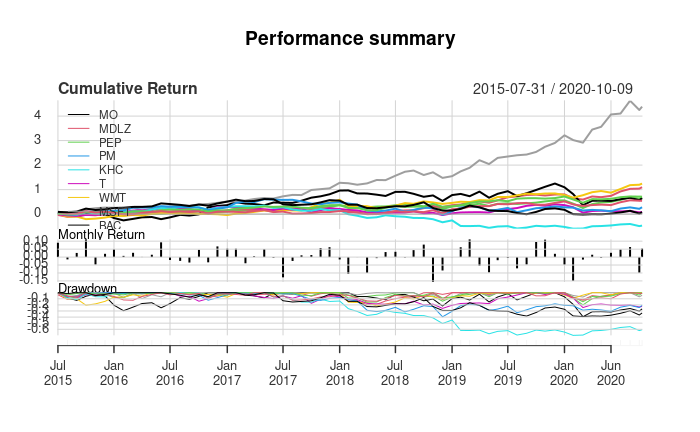

```r
# Plotting a performance summary chart
charts.PerformanceSummary(stock.returns.monthly_xts_4,
                          main="Performance summary")
```

1. Regress all stocks on the index. Show alpha, beta and residual variance. Calculate systematic and firm-specific risk. Are there any significant alphas? (You should double check with the appropriate `PerformanceAnalytics` Functions)

```r
#Regress all stocks on the index
alpha.Stocks <- CAPM.alpha(Ra = stock.returns.monthly_xts_4[,-n], Rb = stock.returns.monthly_xts_4[,n], Rf = 0)
beta.Stocks <- CAPM.beta(Ra = stock.returns.monthly_xts_4[,-n], Rb = stock.returns.monthly_xts_4[,n], Rf = 0)
StdDev.Index <- StdDev(R = stock.returns.monthly_xts_4[,n],
                   clean = "none",
                   method = "pearson")
lm(stock.returns.monthly_xts_4[,-n] ~ stock.returns.monthly_xts_4[,n])
```

```
Call:
lm(formula = stock.returns.monthly_xts_4[, -n] ~ stock.returns.monthly_xts_4[,
    n])

Coefficients:
                                  MO          MDLZ        PEP         PM          KHC         T           WMT
(Intercept)                       -0.0013562   0.0023534   0.0042481  -0.0009117  -0.0153039  -0.0035760   0.0110646
stock.returns.monthly_xts_4[, n]   0.4954135   0.6245419   0.5574535   0.7942816   1.0500114   0.6884746   0.3276921
                                  MSFT        BAC         PG
(Intercept)                        0.0197313  -0.0023052   0.0084237
stock.returns.monthly_xts_4[, n]   0.9269620   1.5336554   0.4576452
```

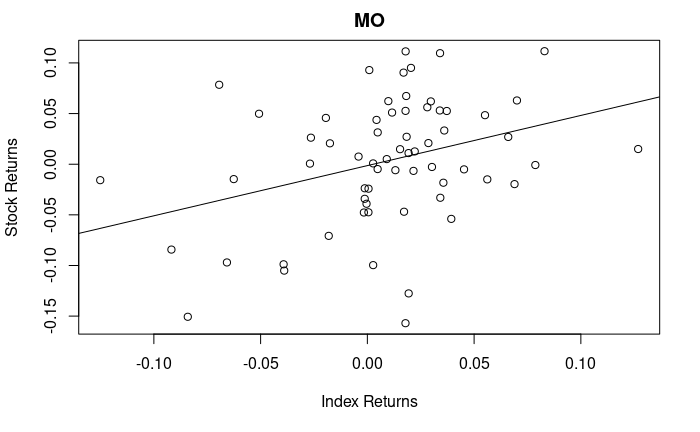

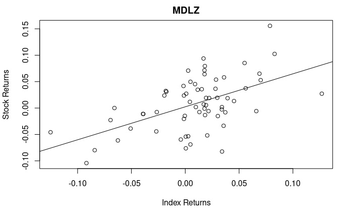

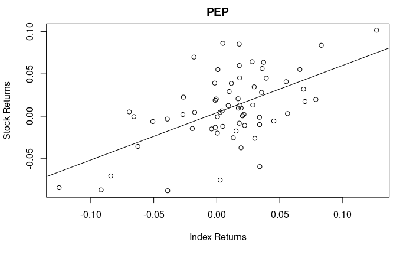

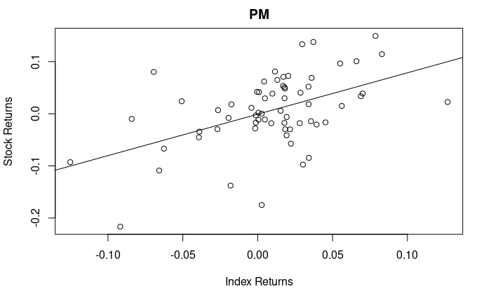

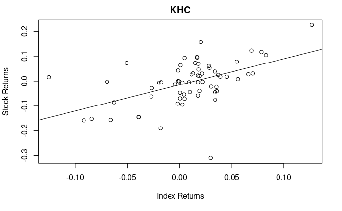

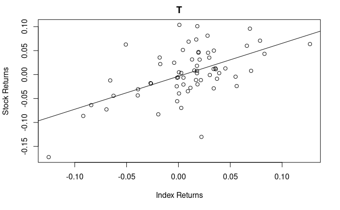

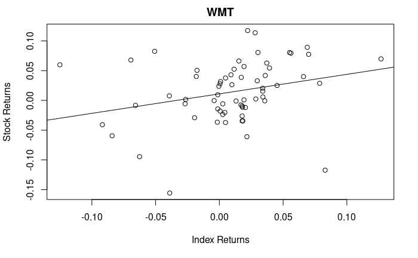

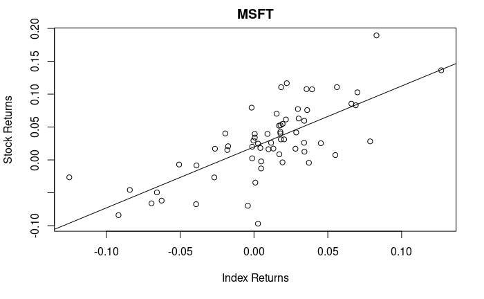

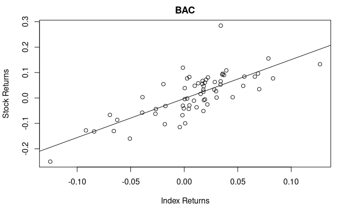

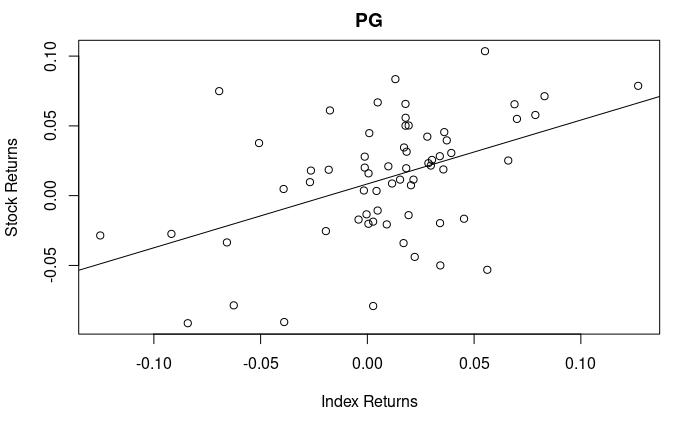

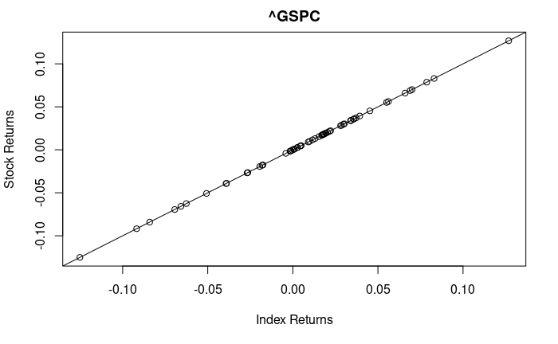

```r
for(i in 1:n) {
plot.default(x = stock.returns.monthly_xts_4[, n],
            y = stock.returns.monthly_xts_4[, i],
            main = stockselection_4[i],
            xlab = "Index Returns",
            ylab = "Stock Returns",
            abline(lm(stock.returns.monthly_xts_4[, i] ~ stock.returns.monthly_xts_4[, n])))
}
```

```r
#Calculate systematic (Market-Specific) Risk by mulitplying Variance (StdDev^2) of the S&P500 and the Beta^2 of each stock
sys.risk <- SystematicRisk(Ra = stock.returns.monthly_xts_4[,-n], Rb = stock.returns.monthly_xts_4[,n], Rf = 0)
sys.risk
```

```
                                          MO       MDLZ        PEP        PM      KHC         T        WMT      MSFT
Systematic Risk to ^GSPC (Rf = 0) 0.07363604 0.09282911 0.08285739 0.1180585 0.156069 0.1023318 0.04870669 0.1377795
                                        BAC         PG
Systematic Risk to ^GSPC (Rf = 0) 0.2279557 0.06802233
```

```r
#Calculate Firm-specific Risk / Residual Variance
firm.specific.risk <- SpecificRisk(Ra = stock.returns.monthly_xts_4[,-n], Rb = stock.returns.monthly_xts_4[,n], Rf = 0)
firm.specific.risk
```

```
                        MO      MDLZ       PEP        PM       KHC         T       WMT      MSFT       BAC        PG
Specific Risk =  0.2016367 0.1451427 0.1180399 0.2066222 0.2618048 0.1493106 0.1706142 0.1331298 0.1926068 0.1325697
```

```r
#Summary
summary.SFM <- table.SFM(Ra = stock.returns.monthly_xts_4[,-n], Rb = stock.returns.monthly_xts_4[,n], scale = NA, Rf = 0, digits = 6)
summary.SFM
```

|  | MO to ^GSPC | MDLZ to ^GSPC | PEP to ^GSPC | PM to ^GSPC | KHC to ^GSPC | T to ^GSPC | WMT to ^GSPC | MSFT to ^GSPC | BAC to ^GSPC | PG to ^GSPC |
| --- | --- | --- | --- | --- | --- | --- | --- | --- | --- | --- |
| Alpha | -0.001356 | 0.002353 | 0.004248 | -0.000912 | -0.015304 | -0.003576 | 0.011065 | 0.019731 | -0.002305 | 0.008424 |
| Beta | 0.495413 | 0.624542 | 0.557454 | 0.794282 | 1.050011 | 0.688475 | 0.327692 | 0.926962 | 1.533655 | 0.457645 |
| Beta+ | 0.266096 | 0.695440 | 0.574158 | 0.760100 | 1.392468 | 0.471309 | 0.434160 | 1.116607 | 1.203603 | 0.580336 |
| Beta- | 0.323004 | 0.682431 | 0.833146 | 0.814310 | 0.495710 | 0.931717 | -0.010909 | 0.760592 | 1.538551 | 0.450362 |
| R-squared | 0.116046 | 0.287069 | 0.326611 | 0.243208 | 0.259158 | 0.316184 | 0.074267 | 0.513225 | 0.579630 | 0.205823 |
| Annualized Alpha | -0.016153 | 0.028609 | 0.052186 | -0.010886 | -0.168951 | -0.042078 | 0.141160 | 0.264239 | -0.027315 | 0.105901 |
| Correlation | 0.340656 | 0.535788 | 0.571499 | 0.493161 | 0.509075 | 0.562302 | 0.272519 | 0.716397 | 0.761334 | 0.453677 |
| Correlation p-value | 0.005879 | 0.000005 | 0.000001 | 0.000035 | 0.000017 | 0.000001 | 0.029361 | 0.000000 | 0.000000 | 0.000167 |
| Tracking Error | 0.216628 | 0.156573 | 0.135946 | 0.210488 | 0.263979 | 0.157453 | 0.198889 | 0.134621 | 0.209709 | 0.156052 |
| Active Premium | -0.088111 | -0.017621 | 0.003822 | -0.054936 | -0.214428 | -0.086875 | 0.061372 | 0.268924 | -0.003624 | 0.046817 |

[output cut: 2 more lines]

```r
# Tracking Error: Der Nachbildungsfehler[1] (englisch tracking error, Abkürzung TE) bezeichnet die ungewollte Abweichung zwischen der Wertentwicklung eines Indexfonds oder eines Portfolios gegenüber der seiner Benchmark über einen bestimmten Beobachtungszeitraum.[2]
```

2. Extract the betas and calculate systematic and unsystematic risk, derive the whole covariance matrix. To do this you can use *CH15_Factor_Models_for_Asset_Returns.pdf (15.3.1)* and the code implemented in the function sharpeFactorEstimator that you find [here](http://financewithr.blogspot.com/2013/06/portfolio-optimization-using-single.html) (please do not just copy everything, but try to understand what you are doing, e.g. check why and if G.hat has the same values as found by the multivariate regression).

```r
#Calculate Beta of Portfolio by average each stocks beta
beta.portfolio <- mean(beta.Stocks)
beta.portfolio
```

```
[1] 0.7456131
```

```r
#Calculate systematic (Market-Specific) Risk of portfolio
sys.risk.portfolio <- mean(sys.risk)
sys.risk.portfolio
```

```
[1] 0.1108246
```

```r
#Calculate unsystematic risk by calculating the mean of the firm-specific risk
unsys.risk.portfolio <- mean(firm.specific.risk)
unsys.risk.portfolio
```

```
[1] 0.1711477
```

```r
#Calculate Covariance Matrix
stock.returns.monthly_data <- as.data.frame((stock.returns.monthly_xts_4))
head(stock.returns.monthly_data)
```

|  | MO | MDLZ | PEP | PM | KHC | T | WMT | MSFT | BAC | PG | ^GSPC |
| --- | --- | --- | --- | --- | --- | --- | --- | --- | --- | --- | --- |
| 2015-07-31 | 0.09043506 | 0.093794968 | 0.020656674 | 0.053325190 | 0.096898308 | -0.011442045 | -0.007582850 | 0.05203882 | 0.05549001 | -0.03400332 | 0.0169570554 |
| 2015-08-31 | -0.01471137 | -0.061378043 | -0.035495433 | -0.066994054 | -0.085692564 | -0.044329330 | -0.094581869 | -0.06194910 | -0.08612998 | -0.07861805 | -0.0625808182 |
| 2015-09-30 | 0.02618842 | -0.007626007 | 0.022613375 | 0.006852134 | -0.028626369 | -0.018674823 | 0.001699312 | 0.01700377 | -0.04344170 | 0.01797109 | -0.0264428316 |
| 2015-10-30 | 0.11158080 | 0.102460067 | 0.083669313 | 0.114332661 | 0.104703788 | 0.043265440 | -0.117211495 | 0.18933564 | 0.07702189 | 0.07126051 | 0.0829831178 |
| 2015-11-30 | -0.04746156 | -0.054159428 | -0.019864981 | -0.011425372 | -0.047295935 | 0.004774821 | 0.027952403 | 0.03944428 | 0.03873643 | -0.02016241 | 0.0005048693 |
| 2015-12-31 | 0.02062949 | 0.030915870 | 0.004592155 | 0.017895478 | -0.004520866 | 0.021977948 | 0.050534539 | 0.02079122 | -0.03170509 | 0.06106373 | -0.0175301852 |

```r
returns <- as.timeSeries(stock.returns.monthly_data[,-n])
factors <- as.vector(as.timeSeries(stock.returns.monthly_data)[,n])
names(data)
```

```r
data <- returns
attr(data, "factors") <- factors
nScenarios <- nrow(data)
X.mat <- cbind(rep(1, times=nScenarios), factors)
G.hat <- solve(qr(X.mat), data) #G.hat is alpha
beta.hat <- G.hat[2, ] #is beta
eps.hat <- data - X.mat %*% G.hat
diagD.hat <- diag(crossprod(eps.hat) / (nScenarios-2))
cov.si = var(factors)*(beta.hat%o%beta.hat) + diag(diagD.hat)
cov.si
```

```
               MO         MDLZ          PEP           PM          KHC            T          WMT         MSFT
MO   0.0039492615 0.0005696307 0.0005084409 0.0007244464 0.0009576919 0.0006279423 0.0002988806 0.0008454613
MDLZ 0.0005696307 0.0025302661 0.0006409648 0.0009132718 0.0012073122 0.0007916140 0.0003767832 0.0010658289
PEP  0.0005084409 0.0006409648 0.0017706854 0.0008151680 0.0010776226 0.0007065787 0.0003363091 0.0009513374
PM   0.0007244464 0.0009132718 0.0008151680 0.0048339765 0.0015354388 0.0010067610 0.0004791864 0.0013555028
KHC  0.0009576919 0.0012073122 0.0010776226 0.0015354388 0.0079258597 0.0013309016 0.0006334670 0.0017919255
T    0.0006279423 0.0007916140 0.0007065787 0.0010067610 0.0013309016 0.0027903833 0.0004153535 0.0011749350
              BAC           PG
MO   0.0013988128 0.0004174079
MDLZ 0.0017634102 0.0005262044
PEP  0.0015739844 0.0004696794
PM   0.0022426746 0.0006692176
KHC  0.0029647345 0.0008846814
T    0.0019439258 0.0005800705
 [ reached getOption("max.print") -- omitted 4 rows ]
```

```r
#Function to implement single-factor model into the portfolio optimization framework
data(stock.returns.monthly_xts_4)
```

```
data set ‘stock.returns.monthly_xts_4’ not found
```

```r
returns <- as.timeSeries(stock.returns.monthly_xts_4)
names(data)
```

```
 [1] "MO"   "MDLZ" "PEP"  "PM"   "KHC"  "T"    "WMT"  "MSFT" "BAC"  "PG"
```

```r
data <- returns[, -c(n)]
factors <- returns[, n]
attr(data, "factors") <- factors
# Sharpe's Single Index Factor Model:
sharpeFactorEstimator <-
function(x, spec=NULL, ...)
{
    # Sharpe Single Index Model:
    data <- getDataPart(x)
    factors <- attr(x, "factors")
    nScenarios <- nrow(data)
    X.mat <- cbind(rep(1, times=nScenarios), factors)
    G.hat <- solve(qr(X.mat), data)
    beta.hat <- G.hat[2, ]
    eps.hat <- data - X.mat %*% G.hat
    diagD.hat <- diag(crossprod(eps.hat) / (nScenarios-2))
    mu <- G.hat[1, ] + G.hat[2, ] * colMeans(factors)
    Sigma <- var(factors)[[1]] * (beta.hat %o% beta.hat) + diag(diagD.hat)

    # Return Value:
    list(mu = mu, Sigma = Sigma)
}
 #Chart the efficient frontier using the parameters estimated by the single factor model
sharpe_1 <- portfolioFrontier(data)
```

[output not shown]

```
Error in portfolioFrontier(data) :
  could not find function "portfolioFrontier"
```

Calculate MVP, TP etc. and work out the differences in weights, portfolio return and portfolio risk.

```r
#weights, portfolio return and portfolio risk of MVP
opt.sd.minv.shrink
plot(opt.sd.minv.shrink, risk.col="StdDev", return.col="mean", main="Minimum Variance Optimization shrink", chart.assets=TRUE, xlim=c(0, 0.2), ylim=c(0,0.02))
#weights, portfolio return and portfolio risk of QUP
opt.sd.maxq.shrink
plot(opt.sd.maxq.shrink, risk.col="StdDev", return.col="mean", main="Quadratic Utility Optimization shrink", chart.assets=TRUE, xlim=c(0, 0.2), ylim=c(-0.08,0.05))
#weights, portfolio return and portfolio risk of tangency portfolio (Highest risk/return ratio)
weight_tp_sharpe <- sharpe_1@portfolio@portfolio[["weights"]][26, ]
return_tp_sharpe <- sharpe_1@portfolio@portfolio[["targetReturn"]][26, ]
risk_tp_sharpe <- sharpe_1@portfolio@portfolio[["targetRisk"]][26, ]
weight_tp_sharpe
return_tp_sharpe
risk_tp_sharpe
```

[output not shown]